# Project 2: Data Mining, Classification, Prediction

SDS322E

# Mining, Classification, Prediction

## Arpan Patel, adp2999

### Introduction

I am using the same Amazon orders dataset from Project 1. The variables within this dataset are Order Date, Order ID, Account Group, Order Quantity, Order Subtotal, Order Tax, Order Net Total, Order Net Total Above Avg, Amazon-Internal Product Category, ASIN, Title, UNSPSC, Brand, Manufacturer, Item Model Number, Seller Name, and Seller State. The Order Net Total Above Avg is a binary variable with 0 representing the net total of the order being below the average and 1 representing a net total above the average. I am interested in finding relationships among my Amazon order history. I downloaded this data directly from my Amazon account history. There are 87 observations of 17 varaibles after all the data points with NAs have been omitted. Within the binary variable, there are 61 observations with the value “0”. This means there are 61 orders that have an order net total below the average order net total. On the other hand, there are 26 observations with the value “1”. This means there are 26 orders that have an order net total above the average order net total.

```r
library(tidyverse)
# read your datasets in here, e.g., with read_csv()
AMZM_orders <- read_csv("/stor/home/adp2999/project2/AMZM_orders.csv",
    col_types = cols(`Order Date` = col_date(format = "%m/%d/%Y"),
        `Order Quantity` = col_number(), `Order Subtotal` = col_number(),
        `Order Net Total Above Avg` = col_number(), `Order Tax` = col_number(),
        `Order Net Total` = col_number()))
# if your dataset needs tidying, do so here
AMZM_orders <- na.omit(AMZM_orders)

# any other code here
data1 <- AMZM_orders
below_avg <- data1 %>% filter(`Order Net Total Above Avg` ==
    "0")
count(below_avg)
```

```
## # A tibble: 1 x 1
##       n
##   <int>
## 1    61
```

```r
above_avg <- data1 %>% filter(`Order Net Total Above Avg` ==
    "1")
count(above_avg)
```

```
## # A tibble: 1 x 1
##       n
##   <int>
## 1    26
```

### Cluster Analysis

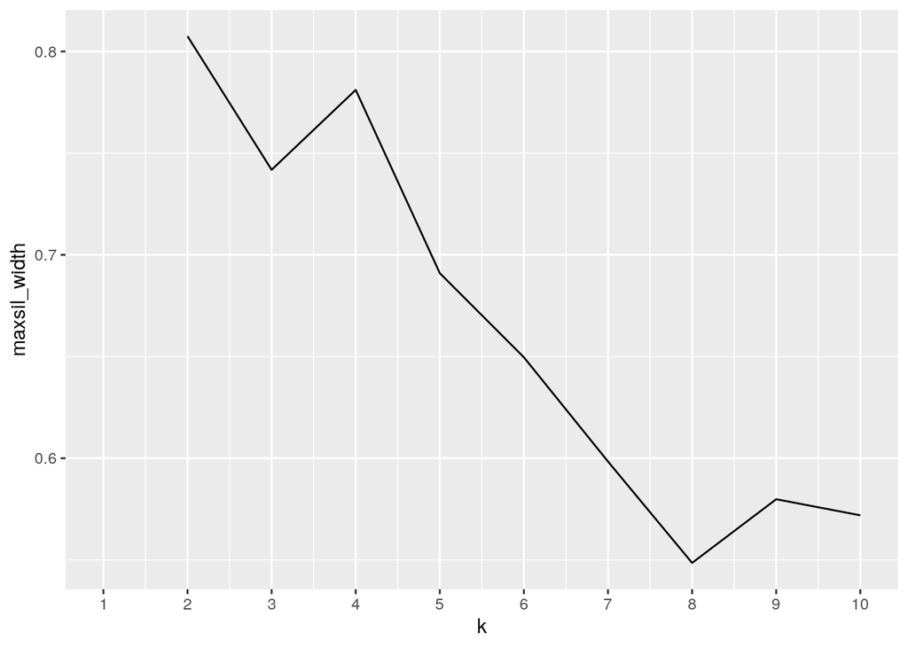

```r
library(cluster)
library(GGally)
# clustering code here
data2 <- data1 %>% select(`Order Quantity`, `Order Subtotal`,
    `Order Tax`)
maxsil_width <- vector()
for (i in 2:10) {
    kmns <- kmeans(data2, centers = i)
    silh <- silhouette(kmns$cluster, dist(data2))
    maxsil_width[i] <- mean(silh[, 3])
}
ggplot() + geom_line(aes(x = 1:10, y = maxsil_width)) + scale_x_continuous(name = "k",
    breaks = 1:10)
```

```r
pam_final <- data2 %>% pam(k = 2)
pam_final$silinfo$avg.width
```

```
## [1] 0.789613
```

```r
pam_final
```

```
## Medoids:
##      ID Order Quantity Order Subtotal Order Tax
## [1,] 52              1          19.99      1.27
## [2,] 36              1         358.99     22.89
## Clustering vector:
##  [1] 1 1 1 1 1 2 2 1 1 2 1 1 1 2 1 1 2 1 1 1 1 1 1 1 1 1 1 1 1 1 1 1 1 2 1 2 2 1
## [39] 2 1 1 1 2 1 1 1 1 1 2 1 1 1 1 1 1 1 1 1 1 1 2 2 1 2 1 1 1 1 1 1 1 1 1 1 1 1
## [77] 2 2 1 1 1 1 1 1 2 1 1
## Objective function:
##    build     swap
## 45.08021 44.18134
##
## Available components:
##  [1] "medoids"    "id.med"     "clustering" "objective"  "isolation"
##  [6] "clusinfo"   "silinfo"    "diss"       "call"       "data"
```

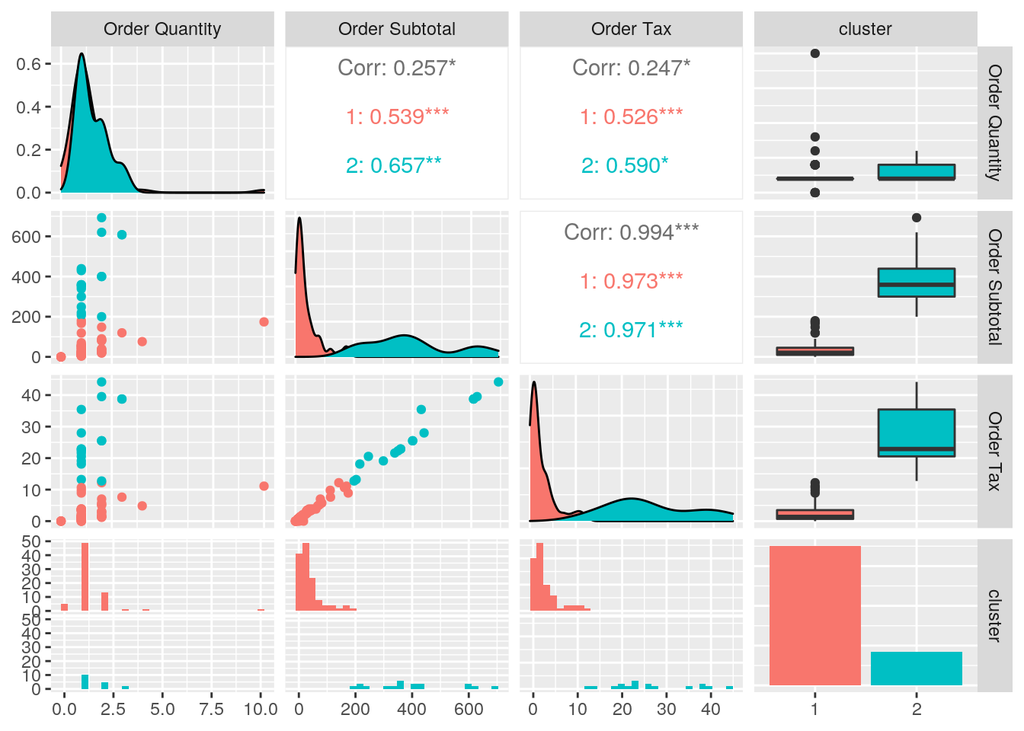

```r
data2 %>% mutate(cluster = as.factor(pam_final$clustering)) %>%
    ggpairs(cols = 1:6, aes(color = cluster))
```

The average silhouette width is 0.789613. This means that a strong structure has been found and a good fit. From the first graph, we can see that the largest avg silhouette width is at a value of k=2. This means that the number of clusters is 2. Since I am only using numbers, Euclidean is used. The two clusters are 1 (red) and 2 (blue). The red cluster has low order quantity, low order subtotal, and low order tax. Cluster 1 is Order Quantity of 1, Order Subtotal of $19.99, and Order Tax of $1.27. On the other hand, Cluster 2 is Order Quantity of 1, Order Subtotal of $358.99, and Order Tax of $22.89. This means that the blue cluster has low order quantity, high order subtotal, and high order tax. The cluster ggplots at the end show that there is lots of overlap between the clusters in terms of Order Quantity. This makes sense as almost all of the amazon orders have an order quantity of 1. Next, the order subtotal and order tax cluster graphs show very little overlap as the difference in prices between the two clusters are large.

### Dimensionality Reduction with PCA

```r
# PCA code here
pca1 <- princomp(data2, cor = T)
summary(pca1, loadings = "T")
```

```
## Importance of components:
##                           Comp.1    Comp.2      Comp.3
## Standard deviation     1.4521370 0.9408149 0.078519301
## Proportion of Variance 0.7029007 0.2950443 0.002055094
## Cumulative Proportion  0.7029007 0.9979449 1.000000000
##
## Loadings:
##                Comp.1 Comp.2 Comp.3
## Order Quantity  0.306  0.952
## Order Subtotal  0.674 -0.211 -0.708
## Order Tax       0.672 -0.222  0.706
```

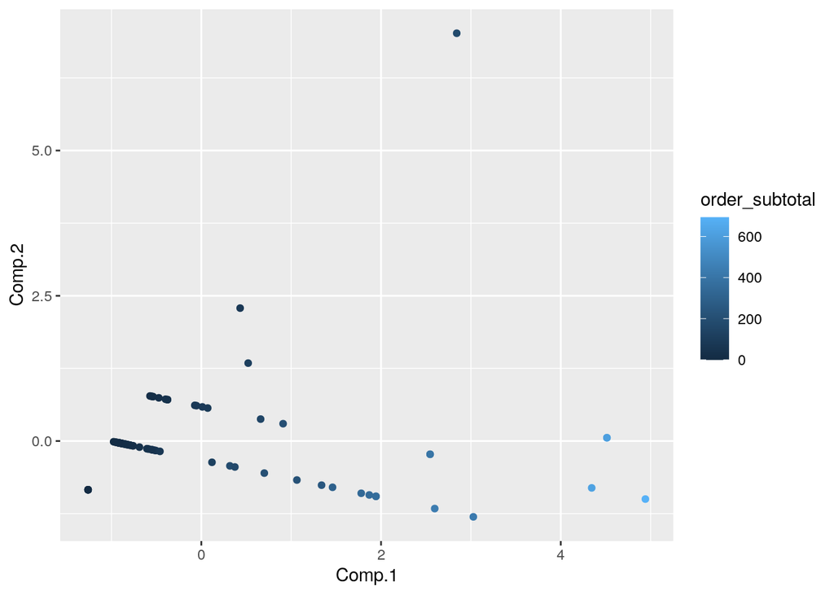

```r
matrix <- pca1$scores
matrix <- matrix %>% as.data.frame() %>% mutate(order_subtotal = data2$`Order Subtotal`)
ggplot(matrix, aes(Comp.1, Comp.2)) + geom_point(aes(color = order_subtotal))
```

```r
cor(data2$`Order Subtotal`, matrix$Comp.1)
```

```
## [1] 0.9784821
```

```r
cor(data2$`Order Subtotal`, matrix$Comp.2)
```

```
## [1] -0.1987003
```

```r
cor(data2$`Order Subtotal`, matrix$Comp.3)
```

```
## [1] -0.05559689
```

The pca1() data shows: First, PC1 has the highest variability of all the variables with a coefficient of 0.7029007. This makes PC1 the general strength axis. In other words, PC1 is positively correlated with all of the variables. This means that a high score on PC1 would result in a high score of all the variables and vice versa. On PC2, a high score on PC2 would result in a high score in order quantity and a low score in order subtotal and order tax, and vice versa. Lastly, on PC3 a high score on PC3 would result in a high score in order tax and a low score in order subtotal, and vice versa.

The cor() data shows: Comp.1 and order subtotal are positively correlated. This means that when order subtotal increases, Comp.1 increases. The correlation between order subtotal and PC1 scores is 0.9784821. On the other hand, Comp.2 and order subtotal are slightly negatively correlated. This means that when order subtotal increases, Comp.2 decreases. The correlation between order subtotal and PC2 scores is -0.1987003. Finally, Comp.3 and order subtotal are even less slightly negatively correlated. This means that when order subtotal increases, Comp.3 decreases. The correlation between order subtotal and PC3 scores is -0.05559689.

### Linear Classifier

```r
# linear classifier code here
y <- data1$`Order Net Total Above Avg`
x <- data1$`Order Net Total`
y <- factor(y, levels = c("0", "1"))
y_hat <- ifelse(x > 87, "1", "0")
data1 %>% select(`Order Net Total`, `Order Net Total Above Avg`) %>%
    mutate(predict = y_hat) %>% head
```

```
## # A tibble: 6 x 3
##   `Order Net Total` `Order Net Total Above Avg` predict
##               <dbl>                       <dbl> <chr>
## 1             127.                            1 1
## 2              33.5                           0 0
## 3              58.5                           0 0
## 4              23.4                           0 0
## 5               8.5                           0 0
## 6             467.                            1 1
```

```r
mean(y == y_hat)
```

```
## [1] 1
```

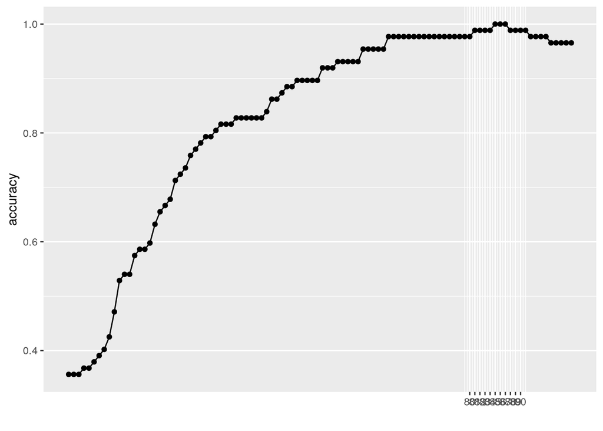

```r
accuracy <- vector()
cutoff <- 1:100
for (i in cutoff) {
    y_hat <- ifelse(x > i, "1", "0")
    accuracy[i] <- mean(y == y_hat)
}
qplot(y = accuracy) + geom_line() + scale_x_continuous(breaks = 80:90)
```

This code predicts the binary output of the ‘Order Net Total Above Avg’ variable. By using the “accuracy” function, we found that the highest accuracy is when ‘Order Net Total’ was greater than 87. In other words, when order net total was greater than $87, the binary output would be 1. And when order net total was less than 87, the binary output would be 0. The model predicted these binary outputs with a 100% accuracy. This means that $87 is the average mean of all the order net totals in the data set. However, this linear classifier only compares one numeric variable to the binary variable.

```r
# linear classifier code here
logistic_reg <- glm(`Order Net Total Above Avg` ~ `Order Quantity` +
    `Order Subtotal` + `Order Tax` + `Order Net Total`, data = data1,
    family = "binomial")
prob_reg <- predict(logistic_reg, type = "response")
class_diag(prob_reg, data1$`Order Net Total Above Avg`, positive = "1")
```

```
##         acc sens spec ppv f1 ba auc
## Metrics   1    1    1   1  1  1   1
```

```r
table(actual = y, predicted = y_hat) %>% addmargins
```

```
##       predicted
## actual  0  1 Sum
##    0   61  0  61
##    1    3 23  26
##    Sum 64 23  87
```

```r
# cross-validation of linear classifier here
set.seed(322)
k = 10
data3 <- sample_frac(data1)  #randomly order rows
folds <- rep(1:k, length.out = nrow(data3))  #create folds
diags <- NULL
i = 1
for (i in 1:k) {
    # create training and test sets
    train <- data3[folds != i, ]
    test <- data3[folds == i, ]
    truth <- test$`Order Net Total Above Avg`
    # train model
    fit <- glm(`Order Net Total Above Avg` == "True" ~ `Order Quantity` +
        `Order Subtotal` + `Order Tax` + `Order Net Total`, data = train,
        family = "binomial")
    # test model
    probs <- predict(fit, newdata = test, type = "response")
    # get performance metrics for each fold
    diags <- rbind(diags, class_diag(probs, truth, positive = "1"))
}
# average performance metrics across all folds
summarize_all(diags, mean)
```

```
##       acc sens spec ppv  f1  ba    auc
## 1 0.70418    0    1 NaN NaN 0.5 0.7473
```

### Non-Parametric Classifier

```r
library(caret)
# non-parametric classifier code here
pfit <- knn3(data1$`Order Net Total Above Avg` ~ data1$`Order Quantity` +
    data1$`Order Subtotal` + data1$`Order Tax` + data1$`Order Net Total`,
    data = data1)
kprob <- predict(pfit, newdata = data1)[, 2]
class_diag(kprob, data1$`Order Net Total Above Avg`, positive = "1")
```

```
##            acc sens   spec   ppv     f1     ba    auc
## Metrics 0.9885    1 0.9836 0.963 0.9811 0.9918 0.9991
```

```r
table(truth = data1$`Order Net Total Above Avg`, predictions = kprob >
    0.5)
```

```
##      predictions
## truth FALSE TRUE
##     0    60    1
##     1     0   26
```

```r
# cross-validation of np classifier here
set.seed(322)
k = 10
data4 <- sample_frac(data1)  #randomly order rows
folds2 <- rep(1:k, length.out = nrow(data4))  #create folds
diags <- NULL
i = 1
for (i in 1:k) {
    # create training and test sets
    train <- data4[folds != i, ]
    test <- data4[folds == i, ]
    truth <- data4$`Order Net Total Above Avg`
    # train model
    fit <- knn3(data4$`Order Net Total Above Avg` == "1" ~ data4$`Order Quantity` +
        data4$`Order Subtotal` + data4$`Order Tax` + data4$`Order Net Total`,
        data = train, )
    # test model
    probs2 <- predict(fit, newdata = test)[, 2]
    # get performance metrics for each fold
    diags <- rbind(diags, class_diag(probs2, truth, positive = "1"))
}
# average performance metrics across all folds
summarize_all(diags, mean)
```

```
##      acc sens   spec   ppv     f1     ba    auc
## 1 0.9885    1 0.9836 0.963 0.9811 0.9918 0.9991
```

### Regression/Numeric Prediction

```r
# regression model code here
regfit <- lm(`Order Net Total` ~ `Order Subtotal` + `Order Tax`,
    data = AMZM_orders)
yhat2 <- predict(regfit)
mean((AMZM_orders$`Order Net Total` - yhat2)^2)
```

```
## [1] 18.81477
```

```r
# cross-validation of regression model here
set.seed(322)
k = 10
regdata <- AMZM_orders[sample(nrow(AMZM_orders)), ]
regfolds <- cut(seq(1:nrow(AMZM_orders)), breaks = k, labels = F)

diags <- NULL
for (i in 1:k) {
    regtrain <- regdata[folds != i, ]
    regtest <- regdata[folds == i, ]

    regfit <- lm(`Order Net Total` ~ `Order Subtotal` + `Order Tax`,
        data = AMZM_orders)
    regyhat <- predict(regfit, newdata = regtest)

    diags <- mean((regtest$`Order Net Total` - regyhat)^2)
}
mean(diags)
```

```
## [1] 0.6305117
```

After the linear regression model was made, it was used to predict the order net total from the order subtotal and order tax. As you can see above, the mean squared error was calculated to be 18.82 which is fairly low. This is the MSE for the overall dataset. Next, a 10 fold CV was performed. The cross validation resulted in a MSE of 0.631. Finally, since the MSE value significantly decreased after cross-validation, there is no overfitting.

### Python

```r
library(reticulate)
use_python("/usr/bin/python3")
val <- "Arpan"
```

```python
# python code here
val = "Patel"
print(r.val, val)
```

```
## Arpan Patel
```

```r
cat(c(val, py$val))
```

```
## Arpan Patel
```

This was a simple use of python where the object “val” was stored as something in R and something different in python. And then the following code prints both the r version and the python version side by side. The final result is my name: Arpan Patel.

### Concluding Remarks

Thank you for the wonderful semester. Although I have never touched a coding language in my whole educational career, I truly enjoyed this class and hope to apply at least some of the skills I learned in the medical field. Have a wonderful Christmas break.